# Death Prediction

cKayce

20 September 2017

# R Markdown

Client’s background: Client is a volunteer organisation that sends its volunteers to visit seniors. As the client has a limited pool of volunteers and a sizeable group of seniors passes on monthly, it will be crucial to visit seniors who have limited life expectancy first.

Use case: Predict the seniors who are on the verge of passing on via RandomForest so that the client can prioritise which group of seniors to meet first

## Prepare the data

Data frame, consisting of categorial variables (such as “exercise” , “smoke”) has been randomly generated. The data is dummified before running the data frame in RandomForest.

```r
#prepare the datasets for analysis ====
order <- c("id", "deathstatus", "exercise", "smoke", "race", "gender", "m.status", "illnesses",
   "incomegroup", "n.child", "agegroup")

sampledata <- sampledata[,order]
head(sampledata)
```

```
##   id deathstatus exercise smoke    race gender m.status    illnesses
## 1  1        dead      yes   yes chinese   male  married heartdisease
## 2  2        dead      yes   yes  indian   male   single heartdisease
## 3  3       alive      yes    no   malay female  married heartdisease
## 4  4        dead       no    no chinese   male   single heartdisease
## 5  5       alive      yes   yes chinese female divorced heartdisease
## 6  6        dead       no    no chinese female   single       others
##   incomegroup            n.child   agegroup
## 1      middle       1-2 children      65-69
## 2      middle            0 child 90 & above
## 3        high       1-2 children      65-69
## 4        high            0 child      80-84
## 5         low 3 or more children      60-64
## 6        high       1-2 children      75-79
```

```r
#dummfy the data into 1/0 factors =====
library(caret)
dmy <- dummyVars("~." , data=sampledata[-2])
sampledata2 <- data.frame(predict(dmy , newdata = sampledata[-2]))
library(dplyr)
deathdf <- select(sampledata , id , deathstatus)
sampledata3 <- merge(deathdf , sampledata2 , by = "id" , all = T)
sampledata3 <- na.omit(sampledata3)
cols <- c("deathstatus" , "exercise.no", "exercise.yes", "smoke.no",
          "smoke.yes", "race.chinese", "race.indian", "race.malay", "race.others",
          "gender.female", "gender.male", "m.status.divorced", "m.status.married",
          "m.status.single", "m.status.widowed", "illnesses.cancer", "illnesses.heartdisease",
          "illnesses.others", "illnesses.stroke", "incomegrouphigh", "incomegrouplow",
          "incomegroupmiddle", "n.child0.child", "n.child1.2.children",
          "n.child3.or.more.children", "agegroup60.64", "agegroup65.69",
          "agegroup70.74", "agegroup75.79", "agegroup80.84", "agegroup85.89",
          "agegroup90...above")
sampledata3[,cols] <- lapply(sampledata3[,cols],as.factor)

#split the data into training and testing data sets =====
set.seed(10000)
sample.ind <- sample(2, nrow(sampledata3) , replace = T , prob = c(0.7 , 0.3))
trainingset <- sampledata3[sample.ind==1,] #training
trainingset2 <- select(trainingset , -deathstatus)
testingset <- sampledata3[sample.ind==2,] #testing
```

## Run RandomForest

```r
#RandomForest =====
VarNames <- names(trainingset)
#exclude the id and response variable from model ====
VarNames <- VarNames[!VarNames %in% c("id" , "deathstatus")]
#Add "+" sign to between independent variables ====
VarNames1 <- paste(VarNames , collapse = "+")
#Add response variable to derive the actual formula ====
rf_form <- as.formula(paste("deathstatus", VarNames1 , sep = "~"))

library(randomForest)
rf <- randomForest(rf_form ,
                   trainingset ,
                   ntree = 500 ,
                   mtry = 31 ,
                   replace = T ,
                   importance = T ,
                   proximity = T)
```

## Generate OOB Error

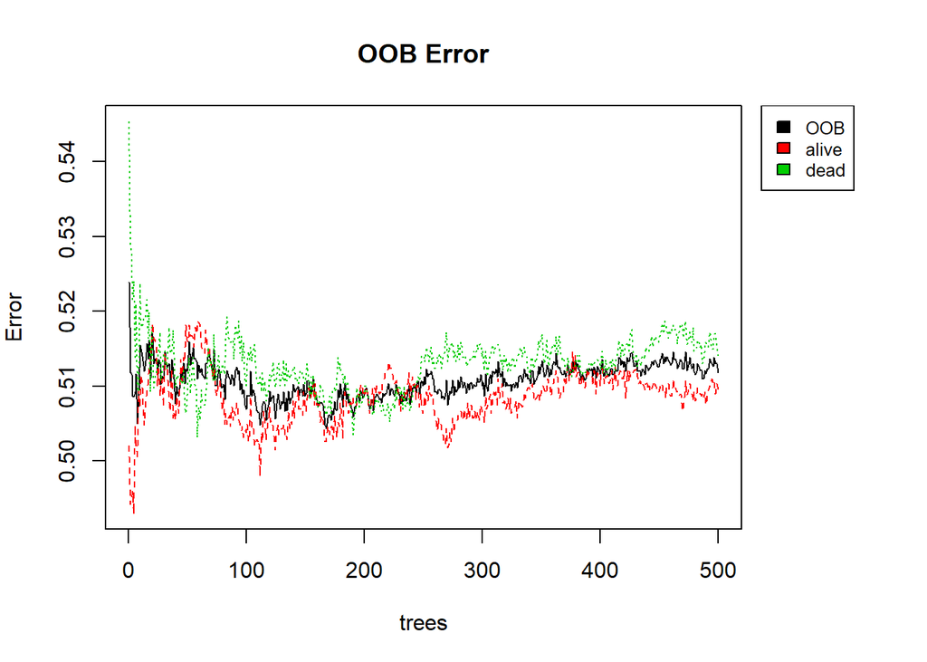

```r
#Plot OOB reate vs No. of Trees graph ====
layout(matrix(c(1,2),nrow = 1),
       widths = c(4,1))
par(mar=c(5,4,4,0))
plot(rf, main = "OOB Error")
par(mar=c(5,0,4,2))
plot(c(0,1),type="n",axes = F, xlab = "" , ylab = "")
legend("top", colnames(rf$err.rate),col = 1:4,cex = 0.8, fill = 1:4)
```

```r
print(rf)
```

```
##
## Call:
##  randomForest(formula = rf_form, data = trainingset, ntree = 500,      mtry = 31, replace = T, importance = T, proximity = T)
##                Type of random forest: classification
##                      Number of trees: 500
## No. of variables tried at each split: 31
##
##         OOB estimate of  error rate: 51.18%
## Confusion matrix:
##       alive dead class.error
## alive  1704 1770   0.5094991
## dead   1786 1688   0.5141048
```